# autumn-group-project-arya-jasmina-neenam

Rai N, Rana J, Shinde A

2023-12-21

```r
#LOAD PACKAGES
library(tidyverse)
library(janitor)
```

```r
library(ggplot2)
library(lubridate)
library(dplyr)
library(grid)
library(patchwork)

#___________________________----
# IMPORT DATA ----
covid <- read_csv("covid_example_data (1)(1).csv")
head(covid)
```

```
## # A tibble: 6 × 28
##   PID       reprt_creationdt_FALSE case_dob_FALSE case_age case_gender case_race
##   <chr>     <chr>                  <chr>             <dbl> <chr>       <chr>
## 1 3a85e699… 22/03/2020             08/11/2004           16 Male        WHITE
## 2 c6b5281d… 01/02/2020             07/06/1964           57 Male        WHITE
## 3 53495ad0… 10/02/2020             06/04/1944           77 Female      BLACK
## 4 2948a265… 20/03/2020             25/06/1964           57 Female      BLACK
## 5 a5524aad… 26/02/2020             21/12/1964           56 Male        WHITE
## 6 db14eeab… 11/02/2020             21/06/1956           65 Male        BLACK
## # ℹ 22 more variables: case_eth <chr>, case_zip <dbl>, Contact_id <chr>,
## #   sym_startdt_FALSE <chr>, sym_fever <chr>, sym_subjfever <chr>,
## #   sym_myalgia <chr>, sym_losstastesmell <chr>, sym_sorethroat <chr>,
## #   sym_cough <chr>, sym_headache <chr>, sym_resolved <chr>,
## #   sym_resolveddt_FALSE <chr>, contact_household <chr>, hospitalized <chr>,
## #   hosp_admidt_FALSE <chr>, hosp_dischdt_FALSE <chr>, died <chr>,
## #   died_covid <chr>, died_dt_FALSE <chr>, confirmed_case <chr>, …
```

```r
#__________________________----
#CLEAN DATA----
covid <- janitor::clean_names(covid) # cleans the column names

colnames(covid) # checks the new variable names
```

```
##  [1] "pid"                    "reprt_creationdt_false" "case_dob_false"
##  [4] "case_age"               "case_gender"            "case_race"
##  [7] "case_eth"               "case_zip"               "contact_id"
## [10] "sym_startdt_false"      "sym_fever"              "sym_subjfever"
## [13] "sym_myalgia"            "sym_losstastesmell"     "sym_sorethroat"
## [16] "sym_cough"              "sym_headache"           "sym_resolved"
## [19] "sym_resolveddt_false"   "contact_household"      "hospitalized"
## [22] "hosp_admidt_false"      "hosp_dischdt_false"     "died"
## [25] "died_covid"             "died_dt_false"          "confirmed_case"
## [28] "pos_sampledt_false"
```

```r
covid <- rename(covid,
                "date_of_entry_for_case"="reprt_creationdt_false",
                "date_of_birth"="case_dob_false",
                "symptomatic_status"="contact_id" ,
                "date_of_first_symptoms"="sym_startdt_false",
                "symptoms_now_resolved"="sym_resolveddt_false",
                "date_of_hospital_admission"="hosp_admidt_false",
                "date_of_hospital_discharge"="hosp_dischdt_false",
                "date_of_death"= "died_dt_false",
                "date of positive PCR test" = "pos_sampledt_false",
                "case_ethnicity" = "case_eth") #re-names columns to easily understandable text

glimpse(covid) # displays column names in console
```

```
## Rows: 82,101
## Columns: 28
## $ pid                         <chr> "3a85e6992a5ac52f", "c6b5281d5fc50b96", "5…
## $ date_of_entry_for_case      <chr> "22/03/2020", "01/02/2020", "10/02/2020", …
## $ date_of_birth               <chr> "08/11/2004", "07/06/1964", "06/04/1944", …
## $ case_age                    <dbl> 16, 57, 77, 57, 56, 65, 47, 61, 36, 42, 74…
## $ case_gender                 <chr> "Male", "Male", "Female", "Female", "Male"…
## $ case_race                   <chr> "WHITE", "WHITE", "BLACK", "BLACK", "WHITE…
## $ case_ethnicity              <chr> "NON-HISPANIC/LATINO", "NON-HISPANIC/LATIN…
## $ case_zip                    <dbl> 30308, 30308, 30315, 30213, 30004, 30314, …
## $ symptomatic_status          <chr> "Yes-Symptomatic", "Yes-Symptomatic", "Yes…
## $ date_of_first_symptoms      <chr> "20/03/2020", "28/01/2020", "10/02/2020", …
## $ sym_fever                   <chr> "Yes", "No", "Yes", "No", "Yes", "Yes", "N…
## $ sym_subjfever               <chr> "Yes", "No", NA, "Yes", "Yes", "Yes", "No"…
## $ sym_myalgia                 <chr> "No", "Yes", "Yes", "Yes", "Yes", "No", "U…
## $ sym_losstastesmell          <chr> NA, NA, NA, NA, NA, NA, NA, NA, NA, "Yes",…
## $ sym_sorethroat              <chr> "Yes", "No", "Yes", "Yes", "No", "Unk", "Y…
## $ sym_cough                   <chr> "Yes", "Yes", "Yes", "Yes", "Yes", "Yes", …
## $ sym_headache                <chr> "Yes", "No", NA, "Yes", "No", "Unk", "Yes"…
## $ sym_resolved                <chr> "No, still symptomatic", "No, still sympto…
## $ symptoms_now_resolved       <chr> NA, NA, NA, NA, NA, "21/02/2020", NA, NA, …
## $ contact_household           <chr> "Yes", "No", NA, "No", "No", "No", "No", "…
## $ hospitalized                <chr> "No", "No", "Yes", NA, "Yes", "Yes", "Yes"…
## $ date_of_hospital_admission  <chr> NA, NA, "08/02/2020", NA, "26/02/2020", "2…
## $ date_of_hospital_discharge  <chr> NA, NA, NA, NA, NA, "21/02/2020", NA, NA, …
## $ died                        <chr> "No", "No", "No", "No", NA, "Yes", "No", N…
## $ died_covid                  <chr> "No", "No", "No", "No", NA, "Yes", "No", N…
## $ date_of_death               <chr> NA, NA, NA, NA, NA, "21/02/2020", NA, NA, …
## $ confirmed_case              <chr> "Yes", "Yes", "Yes", "Yes", "Yes", "Yes", …
## $ `date of positive PCR test` <chr> "22/03/2020", "01/02/2020", "10/02/2020", …
```

```r
colnames(covid) # check for duplicate rows in the data
```

```
##  [1] "pid"                        "date_of_entry_for_case"
##  [3] "date_of_birth"              "case_age"
##  [5] "case_gender"                "case_race"
##  [7] "case_ethnicity"             "case_zip"
##  [9] "symptomatic_status"         "date_of_first_symptoms"
## [11] "sym_fever"                  "sym_subjfever"
## [13] "sym_myalgia"                "sym_losstastesmell"
## [15] "sym_sorethroat"             "sym_cough"
## [17] "sym_headache"               "sym_resolved"
## [19] "symptoms_now_resolved"      "contact_household"
## [21] "hospitalized"               "date_of_hospital_admission"
## [23] "date_of_hospital_discharge" "died"
## [25] "died_covid"                 "date_of_death"
## [27] "confirmed_case"             "date of positive PCR test"
```

```r
duplicated(covid)# produces a list of TRUE/FALSE statements for duplicated or not
```

[output not shown]

[output cut: 6827 more lines]

```r
sum() # sums all the TRUE statements
```

```
## [1] 0
```

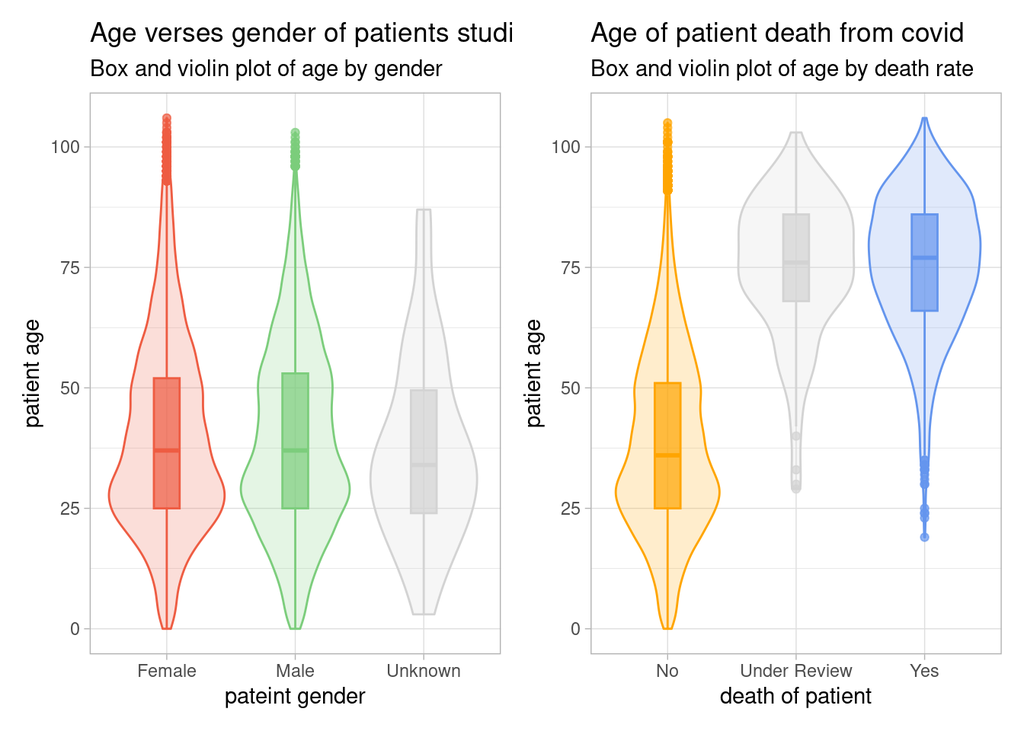

```r
covid <- covid[!(is.na(covid$case_age)),] # omits NA from case_age data

covid <- covid[!(is.na(covid$died_covid)),] #omits NA from died_covid data

covid <- covid[!(is.na(covid$case_gender)),]#omits NA from case_gender data

#___________________________----
#COMPARATIVE GRAPH OF AGE AND GENDER OF PATIENTS STUDIED----


pal <- c("tomato2","palegreen3", "lightgrey")

p1 <- covid %>%
  ggplot(aes(x = case_gender, # gender displayed on X-axis
             y = case_age, # age displayed on Y-Axis
             fill = case_gender,
             colour = case_gender))+
  geom_violin(alpha = 0.2)+
  geom_boxplot(width = 0.2,
               alpha = 0.7)+ # adds scale
  scale_fill_manual(values = pal)+
  scale_colour_manual(values = pal)+
  theme_light()+ # adds in 'light' theme for cohesion between plots
  theme(legend.position = "none")+
  labs(
    x = "pateint gender", #x-axis title
    y = "patient age", #y-axis title
    title = "Age verses gender of patients studied", # graph title
    subtitle = "Box and violin plot of age by gender")# graph sub-title


#___________________________----
#COMPARATIVE GRAPH OF AGE AND DATE TO SHOW DEATH RATE----

pal <- c("orange", "lightgrey", "cornflowerblue")

p2 <- covid %>%
  ggplot(aes(x = died_covid,# weather they died or not displayed on x-axis
             y = case_age, # age of patient recorded
             fill = died_covid,
             colour = died_covid))+
  geom_violin(alpha = 0.2)+
  geom_boxplot(width = 0.2,
               alpha = 0.7)+ # adds scale
  scale_fill_manual(values = pal)+
  scale_colour_manual(values = pal)+
  theme_light()+ # adds in 'light' theme for cohesion between plots
  theme(legend.position = "none")+
  labs(
    x = "death of patient",
    y = "patient age",
    title = "Age of patient death from covid",
    subtitle = "Box and violin plot of age by death rate")

#__________________________----
#COMBINING PLOTS INTO ONE FIGURE----

(p1+p2)+
plot_layout(guides = "collect") #combines plot 1 and 2 in one figure
```

Figure 1. Plot A shows the roughly even distribution of ages of male and female patients in the data set. Plot B is a comparative plot to show the effect that a patients age has on their death rate, with a distribution being showing that the older the patient, the higher the mortality rate.These two figures provide an overview of the data set as a whole.

```r
#LOAD PACKAGES
library(tidyverse)
library(ggplot2)
library(dplyr)
library(patchwork)

#___________________________----
# IMPORT DATA ----
covid <- read_csv("covid_example_data (1)(1).csv")
head(covid)
```

```
## # A tibble: 6 × 28
##   PID       reprt_creationdt_FALSE case_dob_FALSE case_age case_gender case_race
##   <chr>     <chr>                  <chr>             <dbl> <chr>       <chr>
## 1 3a85e699… 22/03/2020             08/11/2004           16 Male        WHITE
## 2 c6b5281d… 01/02/2020             07/06/1964           57 Male        WHITE
## 3 53495ad0… 10/02/2020             06/04/1944           77 Female      BLACK
## 4 2948a265… 20/03/2020             25/06/1964           57 Female      BLACK
## 5 a5524aad… 26/02/2020             21/12/1964           56 Male        WHITE
## 6 db14eeab… 11/02/2020             21/06/1956           65 Male        BLACK
## # ℹ 22 more variables: case_eth <chr>, case_zip <dbl>, Contact_id <chr>,
## #   sym_startdt_FALSE <chr>, sym_fever <chr>, sym_subjfever <chr>,
## #   sym_myalgia <chr>, sym_losstastesmell <chr>, sym_sorethroat <chr>,
## #   sym_cough <chr>, sym_headache <chr>, sym_resolved <chr>,
## #   sym_resolveddt_FALSE <chr>, contact_household <chr>, hospitalized <chr>,
## #   hosp_admidt_FALSE <chr>, hosp_dischdt_FALSE <chr>, died <chr>,
## #   died_covid <chr>, died_dt_FALSE <chr>, confirmed_case <chr>, …
```

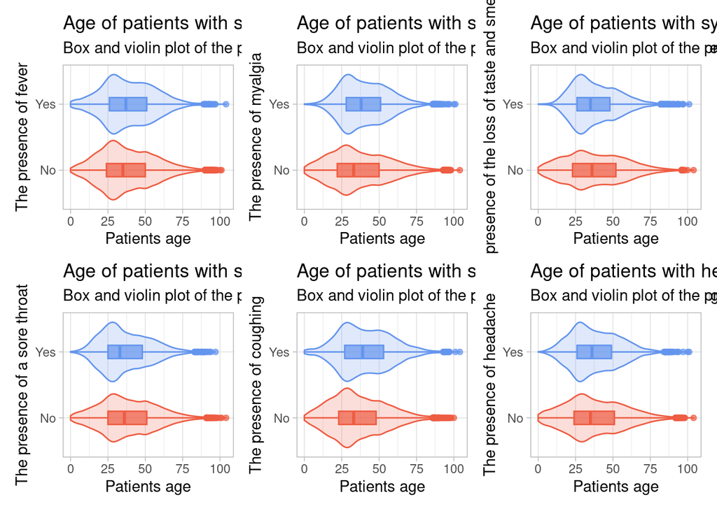

```r
#__________________________----
#CREATING OBJECT----

symptoms_and_ages <- select(.data = covid,
                            case_age, case_race, sym_fever, sym_myalgia, sym_losstastesmell, sym_sorethroat, sym_cough, sym_headache) # Creating a data set with all the columns I am interested in

symptpms_and_ages_omit  <- na.omit(symptoms_and_ages) # getting rid of missing variables in the data set

symptpms_and_ages_omit_no_unknowns  <- filter(symptpms_and_ages_omit,
                                              sym_fever != "Unk",
                                              sym_myalgia != "Unk",
                                              sym_losstastesmell != "Unk",
                                              sym_sorethroat != "Unk",
                                              sym_cough != "Unk",
                                              sym_headache != "Unk") # getting rid of the rows containing unknown variables in the data set


#__________________________----
#COMPARATIVE GRAPHS OF AGE AND PREVELANCE OF CERTAIN SYMPTOMS----

pal <- c("tomato2","cornflowerblue") #colour for graphs

#Graph for age and the presence of fever

p1 <- symptpms_and_ages_omit_no_unknowns %>%
  ggplot(aes(x = sym_fever,
             y = case_age,
             fill = sym_fever,
             colour = sym_fever))+
  geom_violin(alpha = 0.2)+
  geom_boxplot(width = 0.2,
               alpha = 0.7)+ # adds scale
  scale_fill_manual(values = pal)+
  scale_colour_manual(values = pal)+
  coord_flip()+  # flips axis direction
  theme_light()+ # adds in 'light' theme for cohesion between plots
  theme(legend.position = "none")+
  labs( x = "The presence of fever",
        y = "Patients age",
        title = "Age of patients with symptoms of fever",
        subtitle = "Box and violin plot of the presence of fever by patients age")



#Graph for age and the presence of myalgia
p2 <- symptpms_and_ages_omit_no_unknowns %>%
  ggplot(aes(x = sym_myalgia,
             y = case_age,
             fill = sym_myalgia,
             colour = sym_myalgia))+
  geom_violin(alpha = 0.2)+
  geom_boxplot(width = 0.2,
               alpha = 0.7)+# adds scale
  scale_fill_manual(values = pal)+
  scale_colour_manual(values = pal)+
  coord_flip()+  # flips axis direction
  theme_light()+ # adds in 'light' theme for cohesion between plots
  theme(legend.position = "none")+
  labs( x = "The presence of myalgia",
        y = "Patients age",
        title = "Age of patients with symptoms of myalgia",
        subtitle = "Box and violin plot of the presence of myalgia by patients age")



#Graph for age and the presence of the loss of taste and smell
p3 <- symptpms_and_ages_omit_no_unknowns %>%
  ggplot(aes(x = sym_losstastesmell,
             y = case_age,
             fill = sym_losstastesmell,
             colour = sym_losstastesmell))+
  geom_violin(alpha = 0.2)+
  geom_boxplot(width = 0.2,
               alpha = 0.7)+ # adds scale
  scale_fill_manual(values = pal)+
  scale_colour_manual(values = pal)+
  coord_flip()+  # flips axis direction
  theme_light()+ # adds in 'light' theme for cohesion between plots
  theme(legend.position = "none")+
  labs( x = "The presence of the loss of taste and smell",
        y = "Patients age",
        title = "Age of patients with symptoms of loss of taste and smell",
        subtitle = "Box and violin plot of the presence of the loss of taste and smell by patients age")


#Graph for age and the presence of a sore throat
p4 <- symptpms_and_ages_omit_no_unknowns %>%
  ggplot(aes(x = sym_sorethroat,
             y = case_age,
             fill = sym_sorethroat,
             colour = sym_sorethroat))+
  geom_violin(alpha = 0.2)+
  geom_boxplot(width = 0.2,
               alpha = 0.7)+ # adds scale
  scale_fill_manual(values = pal)+
  scale_colour_manual(values = pal)+
  coord_flip()+  # flips axis direction
  theme_light()+ # adds in 'light' theme for cohesion between plots
  theme(legend.position = "none")+
  labs( x = "The presence of a sore throat",
        y = "Patients age",
        title = "Age of patients with symptoms of sore throat",
        subtitle = "Box and violin plot of the presence of a sore throat by patients age")



#Graph for age and the presence of cough
p5 <- symptpms_and_ages_omit_no_unknowns %>%
  ggplot(aes(x = sym_cough,
             y = case_age,
             fill = sym_cough,
             colour = sym_cough))+
  geom_violin(alpha = 0.2)+
  geom_boxplot(width = 0.2,
               alpha = 0.7)+ # adds scale
  scale_fill_manual(values = pal)+
  scale_colour_manual(values = pal)+
  coord_flip()+  # flips axis direction
  theme_light()+ # adds in 'light' theme for cohesion between plots
  theme(legend.position = "none")+
  labs( x = "The presence of coughing",
        y = "Patients age",
        title = "Age of patients with symptoms of coughing",
        subtitle = "Box and violin plot of the presence of coughing by patients age")



#Graph for age and the presence of headache
p6 <- symptpms_and_ages_omit_no_unknowns %>%
  ggplot(aes(x = sym_headache,
             y = case_age,
             fill = sym_headache,
             colour = sym_headache))+
  geom_violin(alpha = 0.2)+
  geom_boxplot(width = 0.2,
               alpha = 0.7)+ # adds scale
  scale_fill_manual(values = pal)+
  scale_colour_manual(values = pal)+
  coord_flip()+  # flips axis direction
  theme_light()+ # adds in 'light' theme for cohesion between plots
  theme(legend.position = "none")+
  labs( x = "The presence of headache",
        y = "Patients age",
        title = "Age of patients with headache symptoms",
        subtitle = "Box and violin plot of the presence of headache by patients age")


# merging all the plots together
(p1+p2+p3+p4+p5+p6)+
  plot_layout(guides = "collect")
```

Figure 2. 6 Plots showing the prevalence of different symptoms at different ages using patients who have been tested for all symptoms.

```r
#LOAD PACKAGES
library(tidyverse)
library(janitor)
library(ggplot2)
library(dplyr)
library(ggplot2)


#__________________________----
# ----IMPORT DATA ----
covid <- read_csv("covid_example_data (1)(1).csv")
head(covid)
```

```
## # A tibble: 6 × 28
##   PID       reprt_creationdt_FALSE case_dob_FALSE case_age case_gender case_race
##   <chr>     <chr>                  <chr>             <dbl> <chr>       <chr>
## 1 3a85e699… 22/03/2020             08/11/2004           16 Male        WHITE
## 2 c6b5281d… 01/02/2020             07/06/1964           57 Male        WHITE
## 3 53495ad0… 10/02/2020             06/04/1944           77 Female      BLACK
## 4 2948a265… 20/03/2020             25/06/1964           57 Female      BLACK
## 5 a5524aad… 26/02/2020             21/12/1964           56 Male        WHITE
## 6 db14eeab… 11/02/2020             21/06/1956           65 Male        BLACK
## # ℹ 22 more variables: case_eth <chr>, case_zip <dbl>, Contact_id <chr>,
## #   sym_startdt_FALSE <chr>, sym_fever <chr>, sym_subjfever <chr>,
## #   sym_myalgia <chr>, sym_losstastesmell <chr>, sym_sorethroat <chr>,
## #   sym_cough <chr>, sym_headache <chr>, sym_resolved <chr>,
## #   sym_resolveddt_FALSE <chr>, contact_household <chr>, hospitalized <chr>,
## #   hosp_admidt_FALSE <chr>, hosp_dischdt_FALSE <chr>, died <chr>,
## #   died_covid <chr>, died_dt_FALSE <chr>, confirmed_case <chr>, …
```

```r
#__________________________----
# ----CLEAN DATA----
covid <- janitor::clean_names(covid) # clean the column names

colnames(covid) # check the new variable names
```

```
##  [1] "pid"                    "reprt_creationdt_false" "case_dob_false"
##  [4] "case_age"               "case_gender"            "case_race"
##  [7] "case_eth"               "case_zip"               "contact_id"
## [10] "sym_startdt_false"      "sym_fever"              "sym_subjfever"
## [13] "sym_myalgia"            "sym_losstastesmell"     "sym_sorethroat"
## [16] "sym_cough"              "sym_headache"           "sym_resolved"
## [19] "sym_resolveddt_false"   "contact_household"      "hospitalized"
## [22] "hosp_admidt_false"      "hosp_dischdt_false"     "died"
## [25] "died_covid"             "died_dt_false"          "confirmed_case"
## [28] "pos_sampledt_false"
```

```r
covid <- rename(covid,
                "date_of_entry_for_case"="reprt_creationdt_false",
                "date_of_birth"="case_dob_false",
                "symptomatic_status"="contact_id" ,
                "date_of_first_symptoms"="sym_startdt_false",
                "symptoms_now_resolved"="sym_resolveddt_false",
                "date_of_hospital_admission"="hosp_admidt_false",
                "date_of_hospital_discharge"="hosp_dischdt_false",
                "date_of_death"= "died_dt_false",
                "date of positive PCR test" = "pos_sampledt_false",
                "case_ethnicity" = "case_eth")
glimpse(covid)
```

```
## Rows: 82,101
## Columns: 28
## $ pid                         <chr> "3a85e6992a5ac52f", "c6b5281d5fc50b96", "5…
## $ date_of_entry_for_case      <chr> "22/03/2020", "01/02/2020", "10/02/2020", …
## $ date_of_birth               <chr> "08/11/2004", "07/06/1964", "06/04/1944", …
## $ case_age                    <dbl> 16, 57, 77, 57, 56, 65, 47, 61, 36, 42, 74…
## $ case_gender                 <chr> "Male", "Male", "Female", "Female", "Male"…
## $ case_race                   <chr> "WHITE", "WHITE", "BLACK", "BLACK", "WHITE…
## $ case_ethnicity              <chr> "NON-HISPANIC/LATINO", "NON-HISPANIC/LATIN…
## $ case_zip                    <dbl> 30308, 30308, 30315, 30213, 30004, 30314, …
## $ symptomatic_status          <chr> "Yes-Symptomatic", "Yes-Symptomatic", "Yes…
## $ date_of_first_symptoms      <chr> "20/03/2020", "28/01/2020", "10/02/2020", …
## $ sym_fever                   <chr> "Yes", "No", "Yes", "No", "Yes", "Yes", "N…
## $ sym_subjfever               <chr> "Yes", "No", NA, "Yes", "Yes", "Yes", "No"…
## $ sym_myalgia                 <chr> "No", "Yes", "Yes", "Yes", "Yes", "No", "U…
## $ sym_losstastesmell          <chr> NA, NA, NA, NA, NA, NA, NA, NA, NA, "Yes",…
## $ sym_sorethroat              <chr> "Yes", "No", "Yes", "Yes", "No", "Unk", "Y…
## $ sym_cough                   <chr> "Yes", "Yes", "Yes", "Yes", "Yes", "Yes", …
## $ sym_headache                <chr> "Yes", "No", NA, "Yes", "No", "Unk", "Yes"…
## $ sym_resolved                <chr> "No, still symptomatic", "No, still sympto…
## $ symptoms_now_resolved       <chr> NA, NA, NA, NA, NA, "21/02/2020", NA, NA, …
## $ contact_household           <chr> "Yes", "No", NA, "No", "No", "No", "No", "…
## $ hospitalized                <chr> "No", "No", "Yes", NA, "Yes", "Yes", "Yes"…
## $ date_of_hospital_admission  <chr> NA, NA, "08/02/2020", NA, "26/02/2020", "2…
## $ date_of_hospital_discharge  <chr> NA, NA, NA, NA, NA, "21/02/2020", NA, NA, …
## $ died                        <chr> "No", "No", "No", "No", NA, "Yes", "No", N…
## $ died_covid                  <chr> "No", "No", "No", "No", NA, "Yes", "No", N…
## $ date_of_death               <chr> NA, NA, NA, NA, NA, "21/02/2020", NA, NA, …
## $ confirmed_case              <chr> "Yes", "Yes", "Yes", "Yes", "Yes", "Yes", …
## $ `date of positive PCR test` <chr> "22/03/2020", "01/02/2020", "10/02/2020", …
```

```r
colnames(covid)
```

```
##  [1] "pid"                        "date_of_entry_for_case"
##  [3] "date_of_birth"              "case_age"
##  [5] "case_gender"                "case_race"
##  [7] "case_ethnicity"             "case_zip"
##  [9] "symptomatic_status"         "date_of_first_symptoms"
## [11] "sym_fever"                  "sym_subjfever"
## [13] "sym_myalgia"                "sym_losstastesmell"
## [15] "sym_sorethroat"             "sym_cough"
## [17] "sym_headache"               "sym_resolved"
## [19] "symptoms_now_resolved"      "contact_household"
## [21] "hospitalized"               "date_of_hospital_admission"
## [23] "date_of_hospital_discharge" "died"
## [25] "died_covid"                 "date_of_death"
## [27] "confirmed_case"             "date of positive PCR test"
```

```r
duplicated(covid)
```

[output not shown]

[output cut: 6827 more lines]

```r
sum()
```

```
## [1] 0
```

```r
covid %>%
  is.na() %>%
  sum()
```

```
## [1] 815982
```

```r
summary(covid)
```

```
##      pid            date_of_entry_for_case date_of_birth         case_age
##  Length:82101       Length:82101           Length:82101       Min.   :-20.00
##  Class :character   Class :character       Class :character   1st Qu.: 25.00
##  Mode  :character   Mode  :character       Mode  :character   Median : 37.00
##                                                               Mean   : 39.69
##                                                               3rd Qu.: 53.00
##                                                               Max.   :106.00
##                                                               NA's   :48
##  case_gender         case_race         case_ethnicity        case_zip
##  Length:82101       Length:82101       Length:82101       Min.   :30000
##  Class :character   Class :character   Class :character   1st Qu.:30213
##  Mode  :character   Mode  :character   Mode  :character   Median :30312
##                                                           Mean   :30250
##                                                           3rd Qu.:30331
##                                                           Max.   :31707
##                                                           NA's   :13
##  symptomatic_status date_of_first_symptoms  sym_fever
##  Length:82101       Length:82101           Length:82101
##  Class :character   Class :character       Class :character
##  Mode  :character   Mode  :character       Mode  :character
##
##
##
##
##  sym_subjfever      sym_myalgia        sym_losstastesmell sym_sorethroat
##  Length:82101       Length:82101       Length:82101       Length:82101
##  Class :character   Class :character   Class :character   Class :character
##  Mode  :character   Mode  :character   Mode  :character   Mode  :character
##
##
##
##
##   sym_cough         sym_headache       sym_resolved       symptoms_now_resolved
##  Length:82101       Length:82101       Length:82101       Length:82101
##  Class :character   Class :character   Class :character   Class :character
##  Mode  :character   Mode  :character   Mode  :character   Mode  :character
##
##
##
##
```

[output cut: 9 more lines]

```
##  Length:82101               Length:82101       Length:82101
##  Class :character           Class :character   Class :character
##  Mode  :character           Mode  :character   Mode  :character
##
##
##
##
##  date_of_death      confirmed_case     date of positive PCR test
##  Length:82101       Length:82101       Length:82101
##  Class :character   Class :character   Class :character
##  Mode  :character   Mode  :character   Mode  :character
##
##
##
##
```

```r
#__________________________----
# ----SELECT DATA SETS REQUIRED----
symptomatic_and_case_race <- select(.data = covid,
                                    case_race, symptomatic_status)
#__________________________----
# ----REMOVE MISSING VARIABLES----
symptomatic_and_case_race_omit  <- na.omit(symptomatic_and_case_race)

#__________________________----
# ----REMOVE UNKNOWN VALUES----
symptomatic_and_case_race_omit_no_unknown   <- filter(symptomatic_and_case_race_omit ,
                                                      case_race != "UNKNOWN")

#__________________________----
# ----CALCULATE OBSERVATION COUNT ACROSS SYMPTOMATIC STATUS----
symptomatic_and_case_race_omit_no_unknown %>% count(symptomatic_status)
```

```
## # A tibble: 3 × 2
##   symptomatic_status     n
##   <chr>              <int>
## 1 No-Asymptomatic     7177
## 2 Unknown              986
## 3 Yes-Symptomatic    39988
```

```r
symptomatic_and_case_race_omit_no_unknown %>% count(symptomatic_status, sort = TRUE)
```

```
## # A tibble: 3 × 2
##   symptomatic_status     n
##   <chr>              <int>
## 1 Yes-Symptomatic    39988
## 2 No-Asymptomatic     7177
## 3 Unknown              986
```

```r
symptomatic_and_case_race_omit_no_unknown %>% count(symptomatic_status, case_race, sort = TRUE)
```

```
## # A tibble: 16 × 3
##    symptomatic_status case_race                            n
##    <chr>              <chr>                            <int>
##  1 Yes-Symptomatic    BLACK                            18143
##  2 Yes-Symptomatic    WHITE                            17215
##  3 No-Asymptomatic    BLACK                             3721
##  4 Yes-Symptomatic    OTHER                             2802
##  5 No-Asymptomatic    WHITE                             2693
##  6 Yes-Symptomatic    ASIAN                             1737
##  7 Unknown            BLACK                              545
##  8 No-Asymptomatic    OTHER                              474
##  9 Unknown            WHITE                              355
## 10 No-Asymptomatic    ASIAN                              281
## 11 Unknown            OTHER                               53
## 12 Yes-Symptomatic    AMERICAN INDIAN/ALASKA NATIVE       50
## 13 Yes-Symptomatic    NATIVE HAWAIIAN/PACIFIC ISLANDER    41
## 14 Unknown            ASIAN                               33
## 15 No-Asymptomatic    AMERICAN INDIAN/ALASKA NATIVE        5
## 16 No-Asymptomatic    NATIVE HAWAIIAN/PACIFIC ISLANDER     3
```

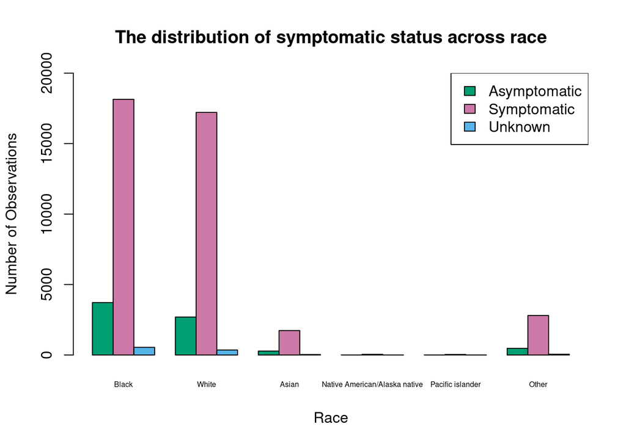

```r
#__________________________----
# ----ASSIGN THE COLOURS FOR THE KEY, LABEL THE KEY AND RACES----
colors = c("#009E73", "#CC79A7", "#56B4E9")

#__________________________----
# ----LABEL THE KEY AND RACES----
race <- c("Black", "White", "Asian", "Native American/Alaska native", "Pacific islander", "Other")
symptomatic_status <- c("Asymptomatic", "Symptomatic", "Unknown")

#__________________________----
# ----CREATE MATRIX----
#the matrix creates a data structure
Values <- matrix(c( 3721, 2693, 281, 5, 3, 474, 18143, 17215, 1737, 50, 41, 2802, 545, 355, 33, 5, 3, 53),
                 nrow = 3, ncol = 6, byrow = TRUE) #nrow tells us there are 3 rows (symptomatic_status) and ncol tells us there are 6 columns (race)

#__________________________----
# ----CREATE BAR CHART----
barplot(Values, main = "The distribution of symptomatic status across race", names.arg = race,
        xlab = "Race", ylab = "Number of Observations",
        #set limits and arrange font sizes
        ylim=c(0,20000),
        cex.name=0.50,
        col = colors, beside = TRUE)

#__________________________----
# ----ADD LEGEND FOR THE KEY----
legend("topright", symptomatic_status, cex = 1, fill = colors)
```

Figure 3. The figure demonstrates the distribution of the symptomatic status of COVID-19 across the six populations of race (Black, White,Asian,Native American/Alaska native, Pacific Islander and Other). The symptomatic status was measured in number of observations across a population.

**Reference List**

1. Chang, W. (2024) R graphics cookbook, 2nd edition, 3.3 Making a Bar Graph of Counts. Available at: https://r-graphics.org/recipe-bar-graph-counts (Accessed: 08 January 2024).
2. Holtz, Y. (no date) Basic barplot with GGPLOT2, – the R Graph Gallery. Available at: https://r-graph-gallery.com/218-basic-barplots-with-ggplot2.html (Accessed: 08 January 2024).
3. figure 1. (plot 1 + 2) Leftwich, P.T. (no date) 5023Y:data science for biologists, Chapter 3 loading data,Chapter 4 data wrangling part 1, Chapter 5 data wrangling part 2, Chapter 6 Data visualization with ggplot 2, Chapter 7 Markdown. Available at: https://ueabio.github.io/data-sci-v1/markdown.html (Accessed: 08 January 2024).
4. Leftwich, P.T. (no date) Chapter 7 Markdown: 5023Y, Chapter 7 Markdown | 5023Y. Available at: https://ueabio.github.io/data-sci-v1/markdown.html (Accessed: 08 January 2024).
5. R.K.- (2017) Bar plots, Quick-R: Bar Plots. Available at: https://www.statmethods.net/graphs/bar.html (Accessed: 08 January 2024).